# Correlation Analysis

ChatGPT 4o

2024-11-20

## 1 起源

相关分析（Correlation Analysis）是一种用于衡量两个变量之间线性关系强度和方向的统计方法。其起源可以追溯到19世纪末期，最早由英国统计学家弗朗西斯·高尔顿（Francis Galton）提出，后由卡尔·皮尔逊（Karl Pearson）进一步发展为皮尔逊相关系数。相关分析广泛应用于各种科学领域，帮助研究人员探索变量之间的关联性。

## 2 原理

相关分析的核心思想是度量两个变量之间是否存在线性关系，以及这种关系的强度和方向。最常用的相关系数是皮尔逊相关系数（Pearson Correlation Coefficient），用以衡量两个变量之间的线性关系，其取值范围在-1到1之间。

- **正相关**：相关系数为正值，表示一个变量增加，另一个变量也随之增加。
- **负相关**：相关系数为负值，表示一个变量增加，另一个变量减少。
- **无相关**：相关系数接近于0，表示两个变量之间没有显著的线性关系。

皮尔逊相关系数的计算公式为：

$$r = \frac{\sum (X_i - \bar{X})(Y_i - \bar{Y})}{\sqrt{\sum (X_i -
\bar{X})^2 \sum (Y_i - \bar{Y})^2}}$$

其中，$X_i$ 和 $Y_i$ 分别表示两个变量的观测值，$\bar{X}$ 和 $\bar{Y}$ 分别为变量的均值。

## 3 适用范围

相关分析适用于以下情况：

- **连续型变量**：用于衡量两个连续型变量之间的线性关系。
- **数据呈正态分布**：数据应该满足正态性假设，尤其是皮尔逊相关分析。
- **线性关系**：适用于探究两个变量之间的线性关系，而非复杂的非线性关系。

除了皮尔逊相关系数外，还有其他类型的相关分析方法，例如斯皮尔曼等级相关系数（用于非正态数据）和肯德尔相关系数。

## 4 应用情境

相关分析在许多实际应用中都有广泛的应用，例如：

- **医学研究**：用于分析年龄与血压、体重与胆固醇水平等变量之间的关系。
- **市场营销**：用于分析广告支出与销售额之间的关系，了解广告效果。
- **社会科学**：用于分析教育水平与收入之间的关联性。
- **金融分析**：用于研究股票价格之间的相关性，探索市场联动性。

## 5 优缺点

### 优点

- **简单直观**：相关分析的计算简单，结果易于理解，能够直观地描述变量之间的关系。
- **广泛应用**：适用于多个领域，是研究变量间关系的基础方法。

### 缺点

- **不能确定因果关系**：相关分析只能揭示变量之间是否相关，不能确定因果关系。
- **对异常值敏感**：异常值可能会显著影响相关系数的值，导致结果失真。
- **只能处理线性关系**：相关分析只能衡量线性关系，无法描述复杂的非线性关系。

## 6 在R中的实现及结果解释

在R中，相关分析可以通过`cor()`函数实现。以下是一个实现示例：

```r
# 示例数据：分析年龄与收入之间的关系
set.seed(123)
Age <- rnorm(100, mean = 35, sd = 10)
Income <- rnorm(100, mean = 50000, sd = 15000)

# 计算皮尔逊相关系数
cor_result <- cor(Age, Income, method = "pearson")

# 输出结果
print(cor_result)
```

```
## [1] -0.04953215
```

### 结果解释

在得到相关系数之后，可以通过`cor.test()`函数对相关系数进行显著性检验，以判断两个变量之间的关系是否显著。

```r
# 对相关系数进行显著性检验
cor_test_result <- cor.test(Age, Income, method = "pearson")

# 输出检验结果
print(cor_test_result)
```

```
##
##  Pearson's product-moment correlation
##
## data:  Age and Income
## t = -0.49095, df = 98, p-value = 0.6246
## alternative hypothesis: true correlation is not equal to 0
## 95 percent confidence interval:
##  -0.2435805  0.1483291
## sample estimates:
##         cor
## -0.04953215
```

运行上述代码后，将输出相关系数的显著性检验结果，主要包括以下内容：

- **t值**：用于检验相关系数的统计量。
  $$t = \frac{r \sqrt{n - 2}}{\sqrt{1 - r^2}}$$

其中：$t$为检验统计量，服从自由度为 $n - 2$ 的 t 分布。 $r$为样本的皮尔逊相关系数（Pearson correlation coefficient）。 $n$为样本大小。 $n - 2$为t 分布的自由度。

- **p值（p-value）**：用于判断相关系数是否显著。如果p值小于显著性水平（如0.05），则可以认为两个变量之间的相关性是显著的。
- **置信区间**：表示相关系数的估计范围，用于描述估计值的不确定性。
- **t = -0.491**：表示检验统计量的值。
- **p-value = 0.625**：p>0.05，说明在95%的置信水平下，不拒绝原假设，认为年龄与收入之间的相关性不具显著性。
- **cor = -0.050**：表示两个变量之间的相关系数为-0.05，表明二者之间存在很弱的负相关关系。

### 非参数的相关系数

```r
# 计算斯皮尔曼相关系数
cor_result <- cor(Age, Income, method = "spearman")

# 输出结果
print(cor_result)
```

```
## [1] 0.00390039
```

```r
# 对斯皮尔曼相关系数进行显著性检验
cor.test(Age, Income, method = "spearman")
```

```
##
##  Spearman's rank correlation rho
##
## data:  Age and Income
## S = 166000, p-value = 0.9693
## alternative hypothesis: true rho is not equal to 0
## sample estimates:
##        rho
## 0.00390039
```

```r
# 计算肯德尔相关系数
cor_result <- cor(Age, Income, method = "kendall")
# 输出结果
print(cor_result)
```

```
## [1] 0.005656566
```

```r
# 对肯德尔相关系数进行显著性检验
cor.test(Age, Income, method = "kendall")
```

```
##
##  Kendall's rank correlation tau
##
## data:  Age and Income
## z = 0.083387, p-value = 0.9335
## alternative hypothesis: true tau is not equal to 0
## sample estimates:
##         tau
## 0.005656566
```

### 结果的可视化

可以使用R中的`ggplot2`包对结果进行可视化，以展示两个变量之间的关系。

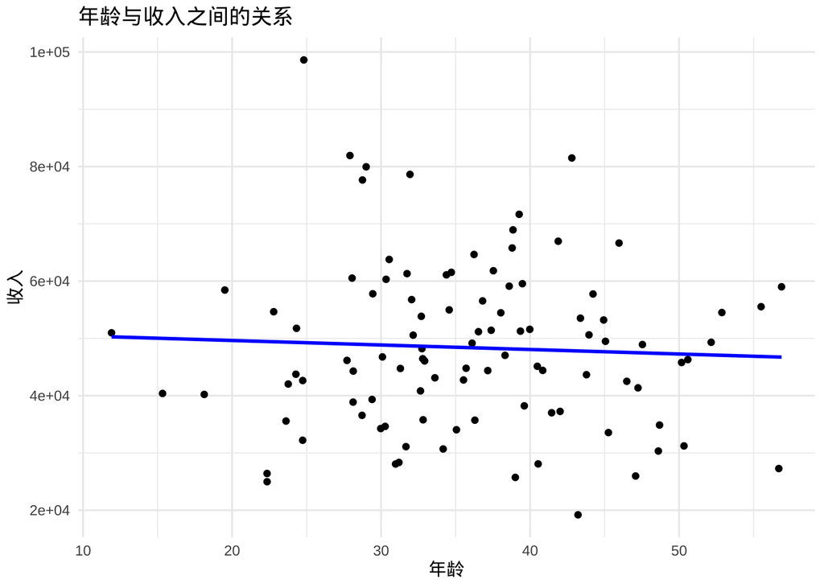

```r
# 加载ggplot2包
library(ggplot2)

# 创建数据框
data <- data.frame(Age = Age, Income = Income)

# 绘制散点图
ggplot(data, aes(x = Age, y = Income)) +
  geom_point() +
  geom_smooth(method = "lm", se = FALSE, color = "blue") +
  labs(title = "年龄与收入之间的关系", x = "年龄", y = "收入") +
  theme_minimal()
```

上述代码将绘制一个散点图，并添加一条线性拟合线，通过图形可以更直观地观察到年龄与收入之间的关系及其趋势。

## 7 小结

- 相关分析用于衡量两个变量之间的线性关系，可以通过相关系数来描述这种关系的强度和方向。
- 适用于连续型变量的数据分析，能够揭示变量之间的关系，但不能确定因果关系。
- 具有简单直观的优点，但只能处理线性关系，且对异常值敏感。
- 可以通过R中的`cor()`函数实现，并结合可视化更直观地展示结果。
- 在医学、市场营销、社会科学等领域有广泛的应用价值。